# report (3)

Title: "UNICEF Data Analytics Story: The Crisis of Severe Wasting"

Author: "Erika Garkule"

format:

html:

```
theme: united

embed-resources: true

code-fold: true
```

```python
!pip install quarto-cli
```

```python
print("Hello Quarto")
```

```
Hello Quarto
```

```python
from google.colab import drive
drive.mount("/content/drive")
```

```python
!quarto render "/content/drive/MyDrive/Colab Notebooks/report.ipynb"
```

[output not shown]

```python
from google.colab import drive
drive.mount('/content/drive')
```

# 🚨 UNICEF Data Story: **The Crisis of Severe Wasting**

> **Wasting** is the *most life-threatening* form of **malnutrition**.

> 👉 *1 in every 13 children* suffers from wasting — a condition where children become **dangerously thin** for their height, leaving them highly vulnerable to disease and death.

> 📝 This report leverages data from **UNICEF**, **World Bank**, and **Kaggle** to uncover alarming global patterns in child malnutrition.
> - Revealing how *poverty, conflict, & geography* shape a child’s chance of survival.

```python
import pandas as pd
```

```python
from google.colab import files
uploaded = files.upload()
```

Upload widget is only available when the cell has been executed in the current browser session. Please rerun this cell to enable.

```
Saving continent_pop.csv to continent_pop (1).csv
Saving indicator_2_cleaned.csv to indicator_2_cleaned (1).csv
Saving world_bank_cleaned.csv to world_bank_cleaned (1).csv
```

```python
# Load CSV files
df_indicator = pd.read_csv("indicator_2_cleaned.csv")
df_world_bank = pd.read_csv("world_bank_cleaned.csv")
df_pop = pd.read_csv("continent_pop.csv")

# Quick overview
df_indicator.head()
```

|  | Country | Indicator | Value | Sex | Unit | Status | Age_Group | Unnamed: 7 | year | cleaning | pasting | year_final |
| --- | --- | --- | --- | --- | --- | --- | --- | --- | --- | --- | --- | --- |
| 0 | Burkina Faso | Weight-for-height <-3 SD (severe wasting) | 0.8 | Total | % | Reported | Under 5 years old | NaN | 2021-10 | 2021-10 | 2021 | 2021 |
| 1 | Afghanistan | Weight-for-height <-3 SD (severe wasting) | 1.4 | Female | % | Reanalysed | Under 5 years old | NaN | 2018 | 2018 | 2018-19 | 2018 |
| 2 | Afghanistan | Weight-for-height <-3 SD (severe wasting) | 1.7 | Male | % | Reanalysed | Under 5 years old | NaN | 2018 | 2018 | 2018 | 2018 |
| 3 | Afghanistan | Weight-for-height <-3 SD (severe wasting) | 1.6 | Total | % | Reanalysed | Under 5 years old | NaN | 2018 | 2018 | 2018 | 2018 |
| 4 | Afghanistan | Weight-for-height <-3 SD (severe wasting) | 3.5 | Female | % | Reanalysed | Under 5 years old | NaN | 2013 | 2013 | 2013 | 2013 |

```python
import pandas as pd
import plotly.express as px

# aggregate
df = (
    pd.read_csv('/content/indicator_2_cleaned.csv')
      .query("Sex=='Total' & Age_Group=='Under 5 years old' & year_final.between(2017,2022)")
      .groupby('Country', as_index=False)['Value']
      .mean()
)

# choropleth world chart
fig = px.choropleth(
    df,
    locations='Country',
    locationmode='country names',
    color='Value',
    color_continuous_scale='Viridis',
    projection='natural earth'
)

# layout
fig.update_layout(
    title={
        'text': "<b>Average Severe Wasting % (2017–22)</b><br>Among Children Under 5",
        'x': 0.5
    },
    margin=dict(l=0, r=0, t=80, b=0)
)

# title and layout
fig.update_coloraxes(colorbar_title_text="<i>Avg Severe Wasting (%)</i>")
fig.update_geos(showframe=False, showcoastlines=False)

fig.show()
```

[interactive chart not shown]

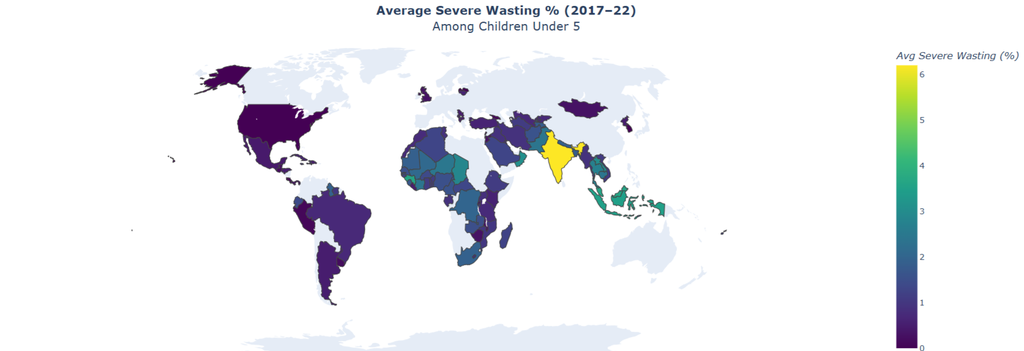

## 🌍 Global Map Highlights

**Severe Wasting Hotspots**  
*Sub-Saharan Africa* and *South Asia* bear the heaviest burden as seen in the map *(unshaded areas indicate lack of data)*, which will further be explored in the next visualisation.

**Why It Matters?**

- The worst-off countries suffer **5 times** higher rates than the lowest-risk regions.
- Reveals entrenched cycles of poverty, conflict and food insecurity.

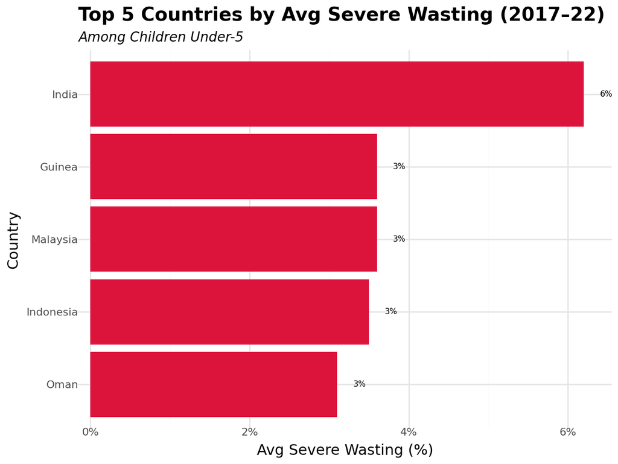

```python
import pandas as pd
from plotnine import (
    ggplot, aes, geom_col, geom_text, coord_flip,
    theme_minimal, labs, scale_y_continuous,
    theme, element_text
)

# Load
df = pd.read_csv('/content/indicator_2_cleaned.csv')
df = df[
    (df.Sex == 'Total') &
    (df.Age_Group == 'Under 5 years old') &
    df.year_final.between(2017, 2022)
]

# Top 5 mean value and  labels
top5 = (
    df.groupby('Country', as_index=False)['Value']
      .mean()
      .nlargest(5, 'Value')
)
top5['label'] = top5['Value'].round(1).astype(int).astype(str) + '%'

# Labels on each bar end
(
    ggplot(top5, aes(x='reorder(Country, Value)', y='Value'))
    + geom_col(fill='crimson')
    + geom_text(
        aes(label='label'),
        va='center',
        ha='left',
        nudge_y=0.2,
        size=6
      )
    + coord_flip()
    + scale_y_continuous(
        labels=lambda vals: [f"{int(v)}%" for v in vals],
        expand=(0, 0.15)
      )
    + theme_minimal()
    + labs(
        title='Top 5 Countries by Avg Severe Wasting (2017–22)',
        subtitle='Among Children Under-5',
        x='Country',
        y='Avg Severe Wasting (%)'
    )
    + theme(
        plot_title=element_text(weight='bold', size=14),
        plot_subtitle=element_text(face='italic', size=10),
        axis_text=element_text(size=8)
    )
)
```

## 📊 Top 5 Countries by Average Severe Wasting (2017–22)

*Among Children under-5 👶*

This bar chart shows the five countries with the highest mean rates of severe wasting among under-5s between 2017 and 2022:

- **India** leads at **6%**, more than **twice** the global average.
- **Guinea**, **Malaysia**, and **Indonesia** cluster around **3–3.5%**, indicating significant pockets of acute malnutrition outside the world’s poorest nations.  
  -**Oman** rounds out the top five at **3%**, underscoring that even middle-income countries face child nutrition challenges.

> ⚠️ **Insight:**  
> These numbers reveal scale and geographic diversity of severe wasting: the most critical hotspots lie in South Asia, meaning that **urgent** interventions are vital to reduce life-threatening under-nutrition among the youngest children. 👶❤️

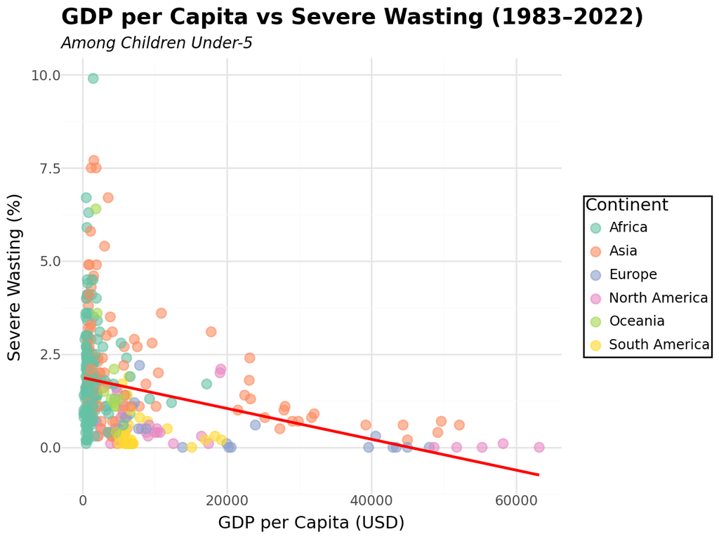

```python
import pandas as pd
from plotnine import (
    ggplot, aes, geom_point, geom_smooth,
    scale_color_brewer, theme_minimal,
    labs, theme, element_text, element_rect
)

# Load wasting data & year_min/year_max
ind = pd.read_csv('/content/indicator_2_cleaned.csv')
years = ind['year_final'].dropna().astype(int)
year_min, year_max = years.min(), years.max()

# severe-wasting percentages
wdf = (
    ind[(ind.Sex=='Total') & (ind.Age_Group=='Under 5 years old')]
      [['Country','year_final','Value']]
      .rename(columns={'Value':'waste_pct'})
)

# GDP per capita
wb = pd.read_csv('/content/world_bank_cleaned.csv')
gdf = (
    wb[wb.year.between(year_min, year_max)]
      [['country','year','gpd_per_capita']]
      .rename(columns={'country':'Country','year':'year_final'})
)

# Load continent legend
cont = (
    pd.read_csv('/content/continent_pop.csv')
      .rename(columns={'Country/Territory':'Country'})
      [['Country','Continent']]
)

# Merge
df_full = (
    wdf
      .merge(gdf, on=['Country','year_final'])
      .merge(cont, on='Country')
      .dropna()
)

# Plot scatter + regression line
(
    ggplot(df_full, aes(x='gpd_per_capita', y='waste_pct', color='Continent'))
    + geom_point(size=3, alpha=0.6)
    + geom_smooth(method='lm', se=False, color='red', size=1)
    + scale_color_brewer(type='qual', palette='Set2')
    + theme_minimal()
    + labs(
        title=f'GDP per Capita vs Severe Wasting ({year_min}–{year_max})',
        subtitle='Among Children Under-5',
        x='GDP per Capita (USD)',
        y='Severe Wasting (%)',
        color='Continent'
    )
    + theme(
        plot_title=element_text(weight='bold', size=14),
        plot_subtitle=element_text(face='italic', size=10),
        legend_background=element_rect(fill='white', colour='black'),
        legend_key_size=12
    )
)
```

## 🌍 GDP per Capita vs Severe Wasting (1983–2022)

*Among Children Under-5*

This scatterplot shows every country-year data point (1983–2022), colored by continent, with a red regression line illustrating the overall relationship between economic wealth and child malnutrition:

- 📉 **Downward trend:** Higher **GDP per capita** generally corresponds to lower **severe wasting rates**.
- 🌍 **Low-income hotspots:** Many **African** and **Asian** countries cluster at GDP < $5 000 with wasting rates above 2–3 %.
- 💰 **Wealth buffer:** High-income nations (e.g., USA, Japan, Kuwait) hover near 0–1 % wasting, highlighting how resources protect child nutrition.
- ⚠️ **Key outlier:** **South Sudan** exhibits very high wasting despite low GDP, signaling acute humanitarian crises.

> 💡 **Insight:**  
> Economic development is a powerful lever for reducing life-threatening malnutrition. Targeting low-GDP, high-wasting regions could save hundreds of thousands of young lives each year.

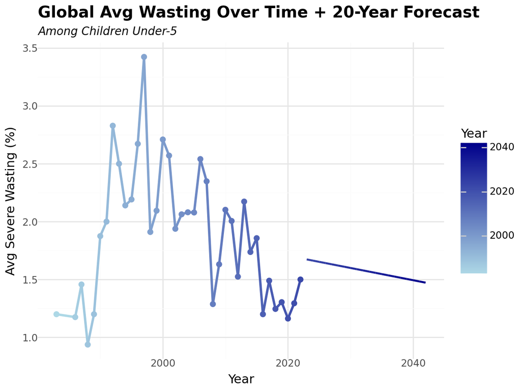

```python
import pandas as pd
import numpy as np
from plotnine import (
    ggplot, aes, geom_line, geom_point,
    scale_color_gradient, theme_minimal,
    labs, theme, element_text
)

# historical series
ind = pd.read_csv('/content/indicator_2_cleaned.csv')
ts = (
    ind.query("Sex=='Total' & Age_Group=='Under 5 years old'")
      .groupby('year_final', as_index=False)['Value']
      .mean()
      .rename(columns={'Value':'avg_waste'})
)
# fit trend
coef = np.polyfit(ts.year_final, ts.avg_waste, 1)
# 20-year forecast
year_max = ts.year_final.max()
pred = pd.DataFrame({
    'year_final': np.arange(year_max+1, year_max+21),
    'avg_waste': coef[0]*np.arange(year_max+1, year_max+21) + coef[1]
})

# plot with continuous gradient on both segments
(
    ggplot(ts, aes(x='year_final', y='avg_waste', color='year_final'))
    + geom_line(size=1.2)
    + geom_point(size=2)
    + geom_line(
        aes(x='year_final', y='avg_waste', color='year_final'),
        data=pred, linetype='dashed', size=1
      )
    + scale_color_gradient(low='lightblue', high='darkblue', name='Year')
    + theme_minimal()
    + labs(
        title='Global Avg Wasting Over Time + 20-Year Forecast',
        subtitle='Among Children Under-5',
        x='Year',
        y='Avg Severe Wasting (%)'
    )
    + theme(
        plot_title=element_text(weight='bold', size=14),
        plot_subtitle=element_text(face='italic', size=10)
    )
)
```

## Global Avg Severe Wasting Over Time + 20-Year Forecast

*Among Children Under-5*

```python
#@title Convert ipynb to HTML in Colab
# Upload ipynb
from google.colab import files
f = files.upload()

# Convert ipynb to html
import subprocess
file0 = list(f.keys())[0]
_ = subprocess.run(["pip", "install", "nbconvert"])
_ = subprocess.run(["jupyter", "nbconvert", file0, "--to", "html"])

# download the html
files.download(file0[:-5]+"html")
```

Upload widget is only available when the cell has been executed in the current browser session. Please rerun this cell to enable.